# Priest spec scaling

## Fetching the data

Data is grabbed from WarcraftLogs via their API. We get the top 1k parses per spec/encounter/difficulty.

Source is at https://github.com/cheald/warcraftlogs-parses

```
$ API_KEY=your_key_here ruby grabber.rb priest
```

Once we have the JSON files, we use a small script to boil them down into a CSV:

```
$ API_KEY=your_key_here ruby distill.rb priest
```

This results in the `csv/priest.csv` that we then consume in R.

Once in R, we load it up:

```r
library(reshape2)
library(ggplot2)
library(dplyr)
library(broom)
data <- read.csv("csv/priest.csv")
data$date <- as.Date(data$date)
cutoff_date = "2016-10-15"
```

## Filtering and plotting

```r
get_encounter_data <- function(encounter_name, difficulty_name, dataset, cutoff=c(0.05, 0.95), bucket_size=1, min_ilvl=855, max_ilvl=875) {
  specs <- unique(dataset$spec)
  d <- filter(dataset, ilvl >= min_ilvl, ilvl <= max_ilvl, encounter == encounter_name, difficulty == difficulty_name, date >= cutoff_date)
  for(bucket in seq(800, 900, by=bucket_size)) {
    for(f_spec in specs) {
      q <- quantile(d[d$spec == f_spec & d$ilvl >= bucket & d$ilvl < bucket + bucket_size,]$dps, cutoff)
      if(!is.na(q[1])) {
        d <- filter(d, !(spec == f_spec & ilvl >= bucket & ilvl < bucket + bucket_size & (dps > q[2] | dps < q[1])))
      }
    }
  }
  return(d)
}
```

Plotting the data is straightforward. Here we plot both boxplots for each spec/ilvl bucket, as well as a smoothed moving average and a linear trendline.

```r
plot_encounter <- function(encounter_name, difficulty_name, dataset=data, bucket_size=2, cutoff=c(0.05, 0.95)) {
  encounter_data <- get_encounter_data(encounter_name, difficulty_name, dataset=dataset, bucket_size=bucket_size, cutoff=cutoff)
  long_data <- melt(encounter_data, id.vars=c("spec", "ilvl"), measure.vars=c("dps"))
  p <- ggplot(data=long_data, aes(x=ilvl, y=value, group=spec, colour=spec)) +
    geom_boxplot(aes(group=interaction(spec, floor(ilvl/bucket_size) * bucket_size))) +
    geom_smooth() + # loess fit
    geom_smooth(linetype = "dashed", method = "lm", se = FALSE) + # linear fit
    labs(y="DPS", x="iLevel", title=paste("Performance:", encounter_name, difficulty_name))
  print(p)
  cat('\r\n\r\n')

  p <- ggplot(data=long_data, aes(x=ilvl, group=spec, colour=spec, fill=spec)) + geom_bar(position="dodge") +
    labs(y="Parses", x="iLevel", title=paste("Parses:", encounter_name, difficulty_name))
  print(p)
  cat('\r\n\r\n')
}
```

## Results

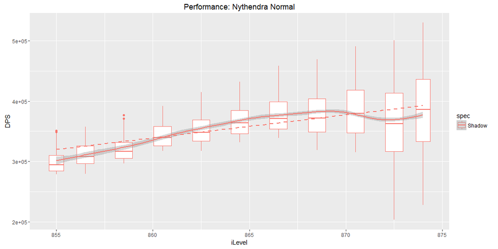

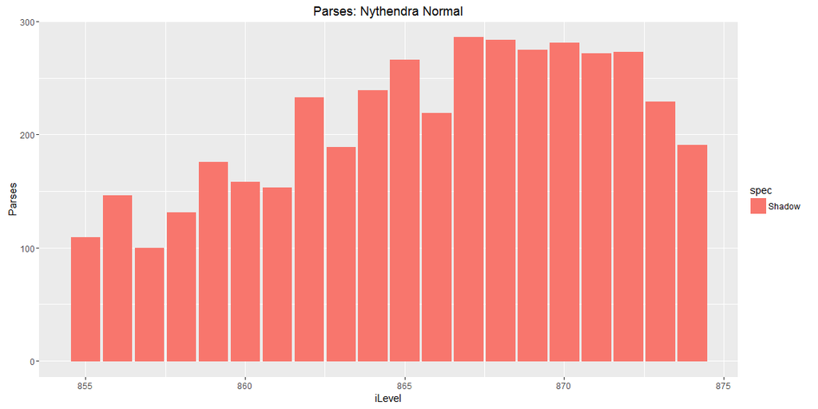

```r
plot_encounter("Nythendra", "Normal")
```

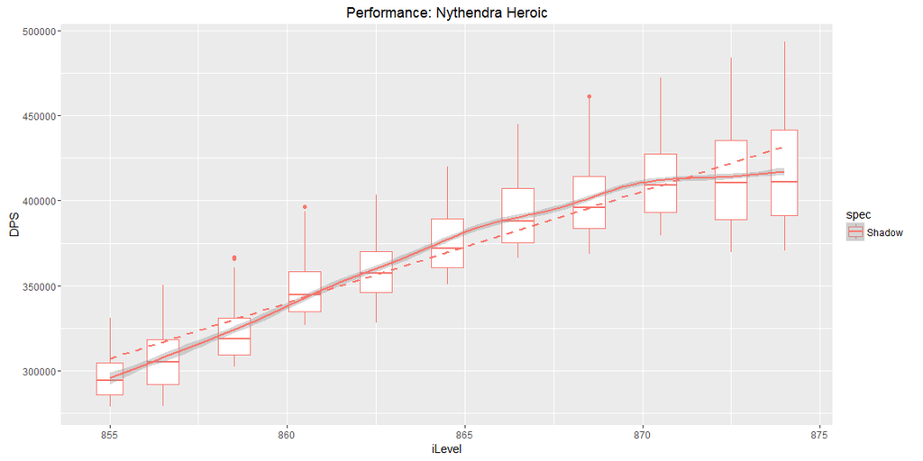

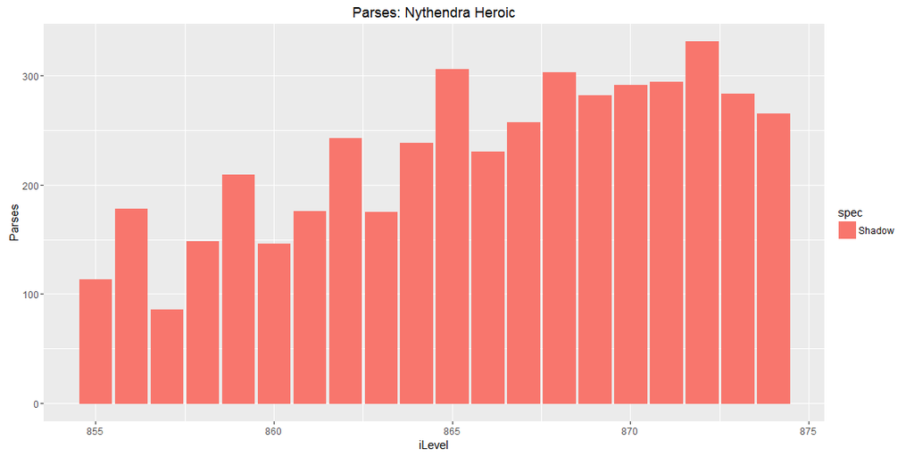

```r
plot_encounter("Nythendra", "Heroic")
```

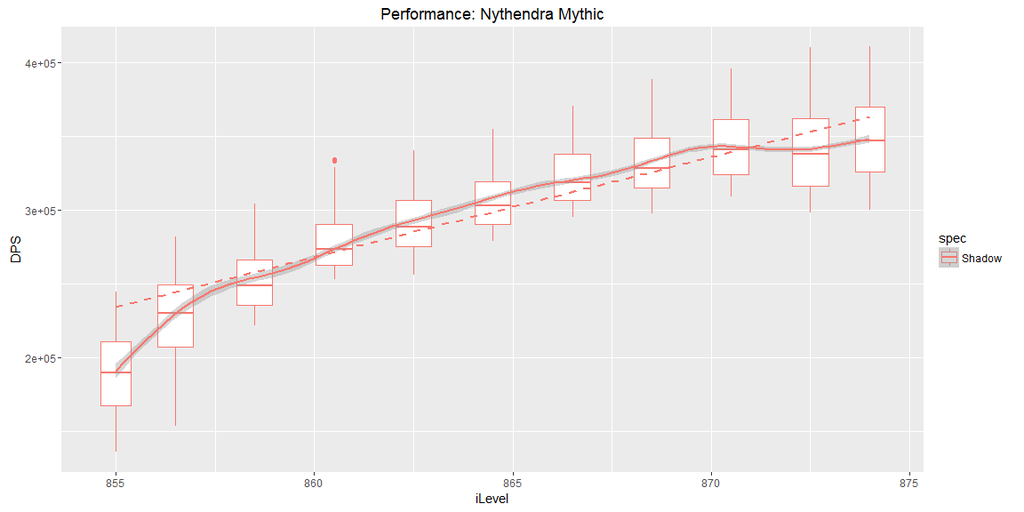

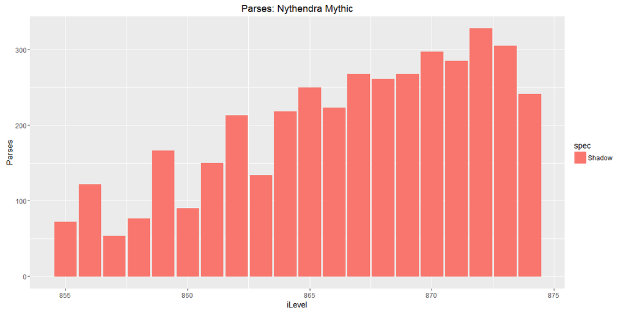

```r
plot_encounter("Nythendra", "Mythic")
```

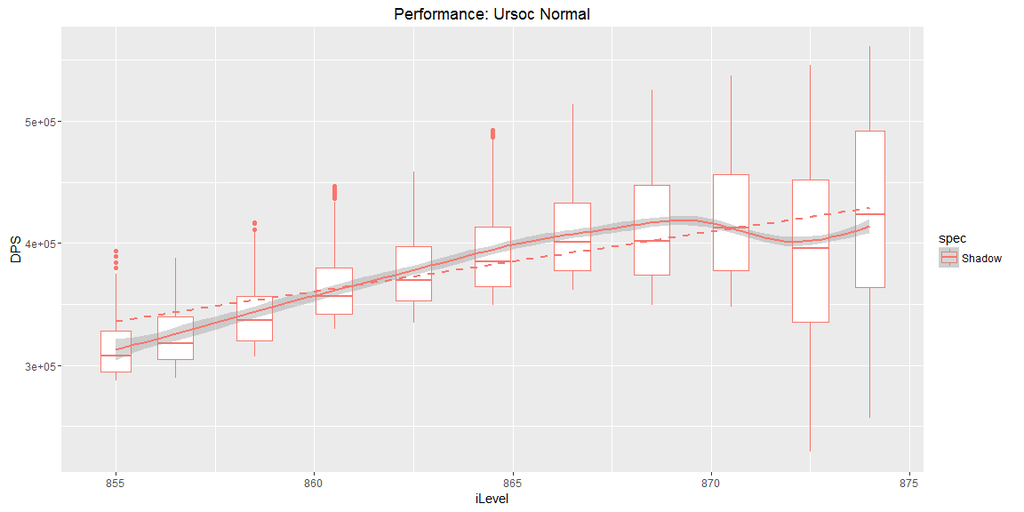

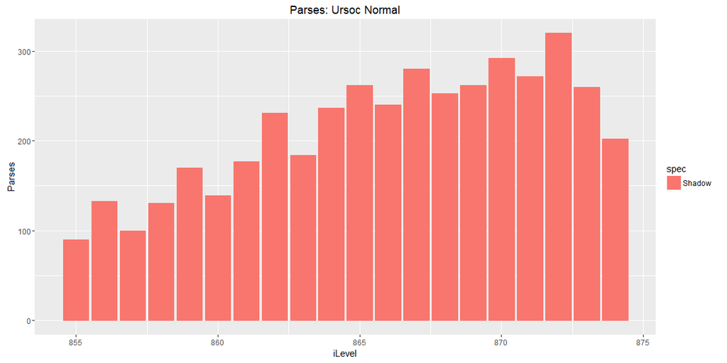

```r
plot_encounter("Ursoc", "Normal")
```

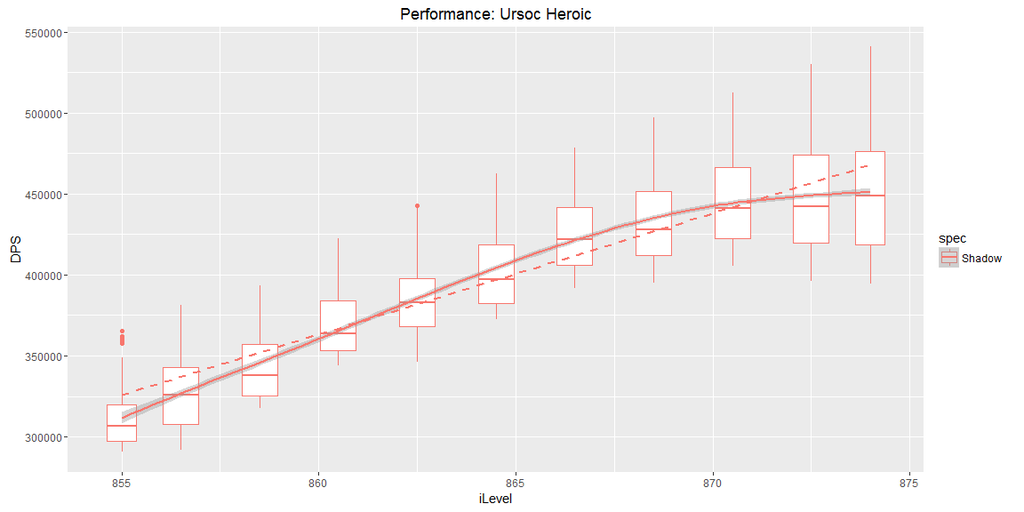

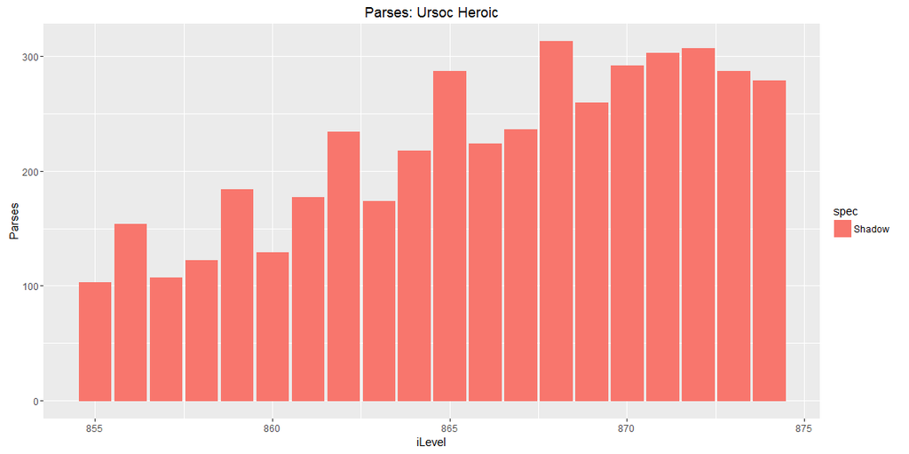

```r
plot_encounter("Ursoc", "Heroic")
```

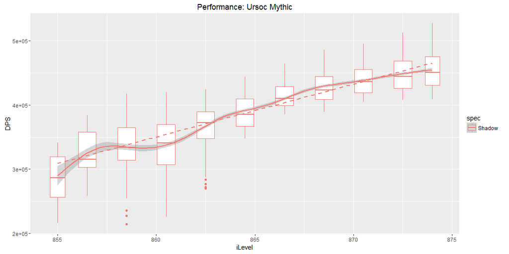

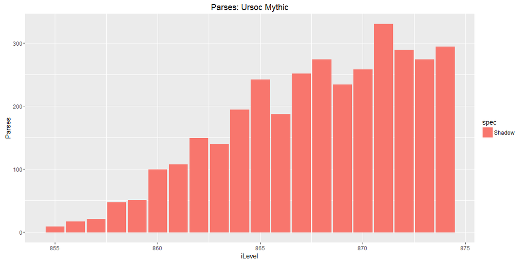

```r
plot_encounter("Ursoc", "Mythic")
```

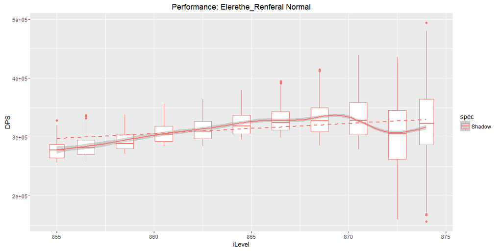

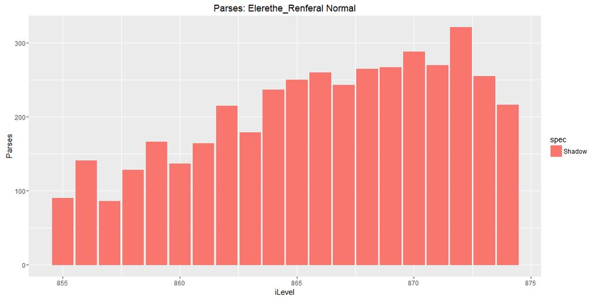

```r
plot_encounter("Elerethe_Renferal", "Normal")
```

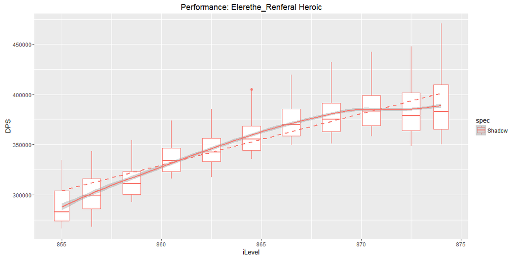

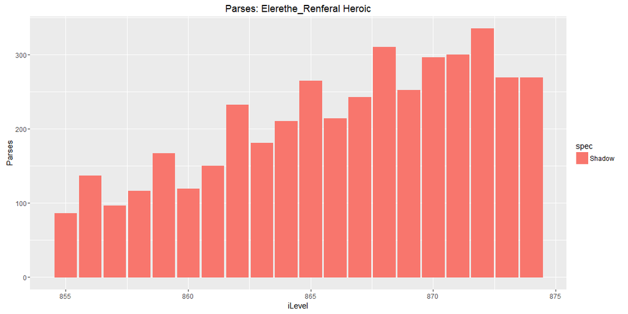

```r
plot_encounter("Elerethe_Renferal", "Heroic")
```

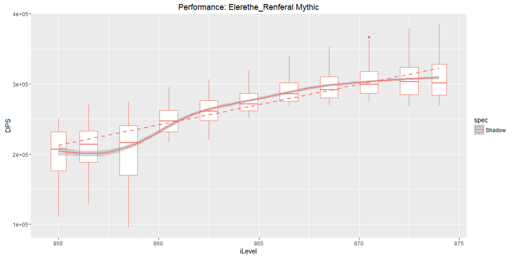

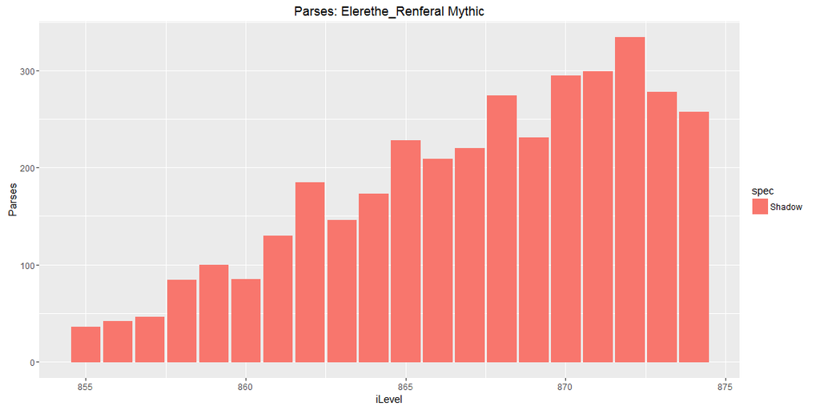

```r
plot_encounter("Elerethe_Renferal", "Mythic")
```

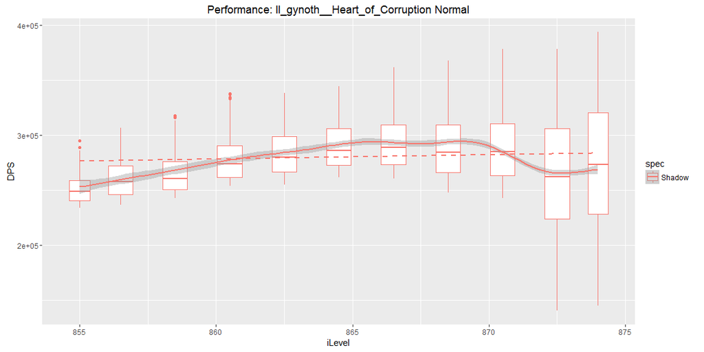

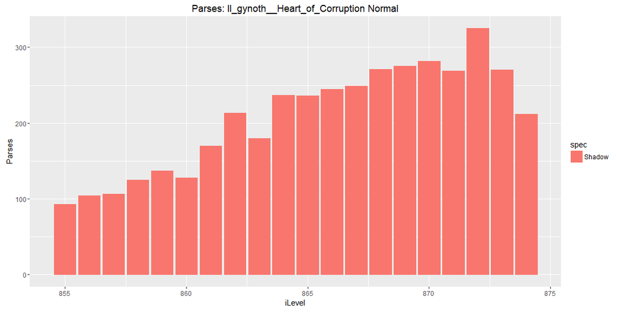

```r
plot_encounter("Il_gynoth__Heart_of_Corruption", "Normal")
```

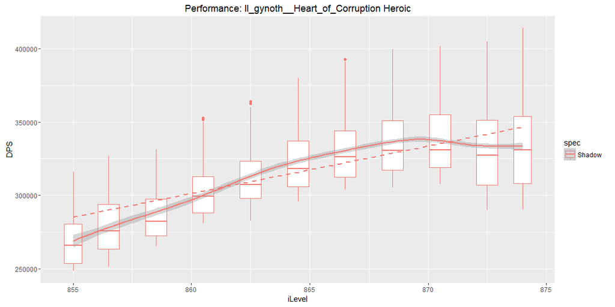

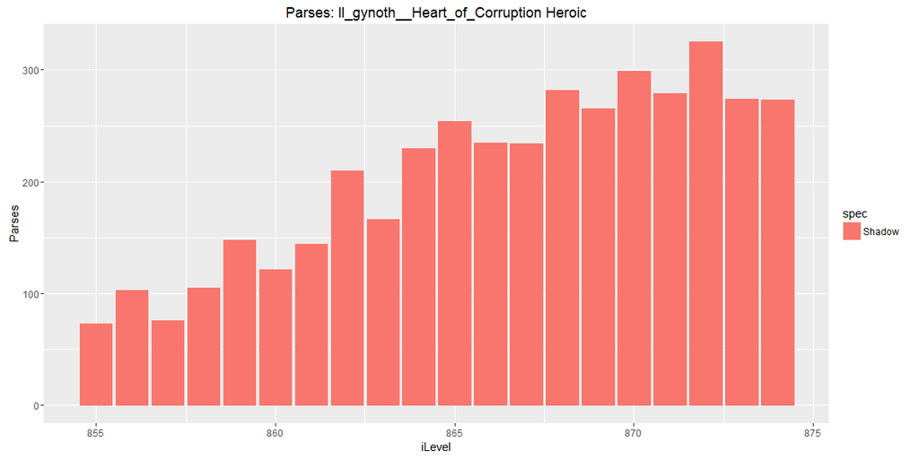

```r
plot_encounter("Il_gynoth__Heart_of_Corruption", "Heroic")
```

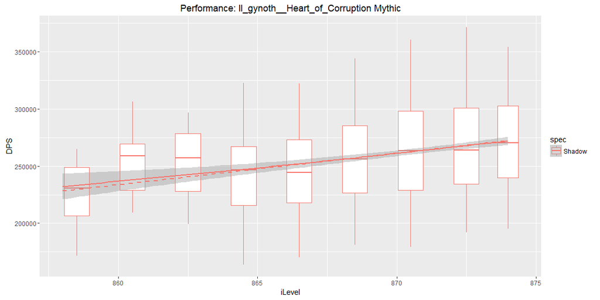

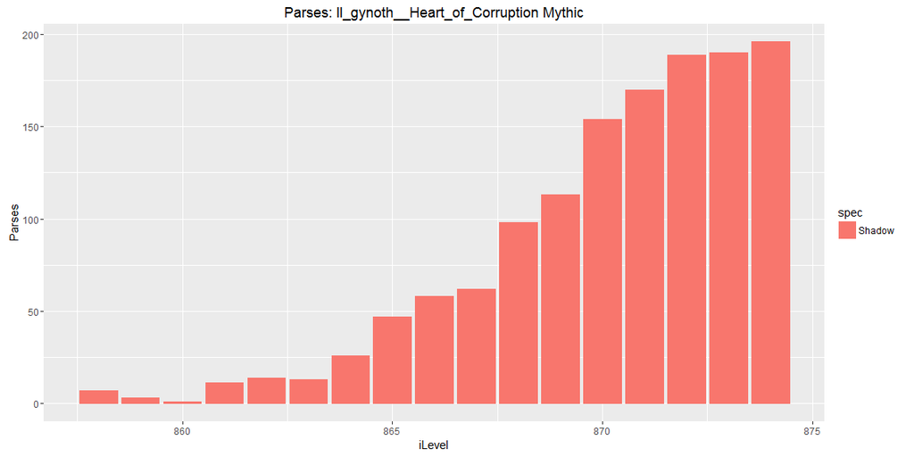

```r
plot_encounter("Il_gynoth__Heart_of_Corruption", "Mythic")
```

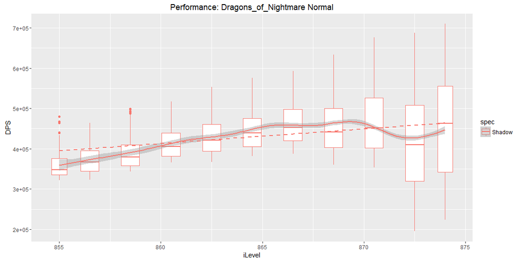

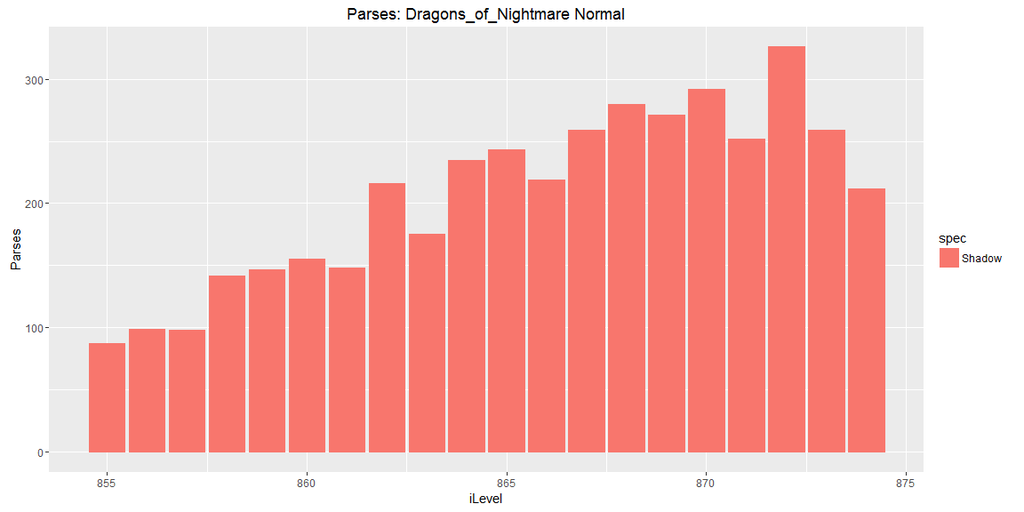

```r
plot_encounter("Dragons_of_Nightmare", "Normal")
```

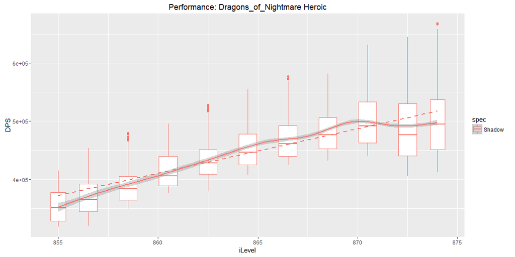

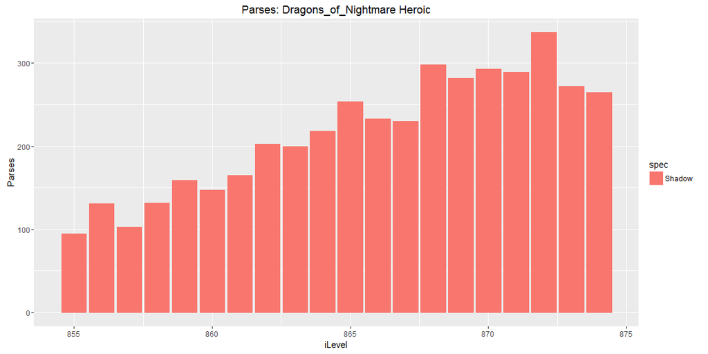

```r
plot_encounter("Dragons_of_Nightmare", "Heroic")
```

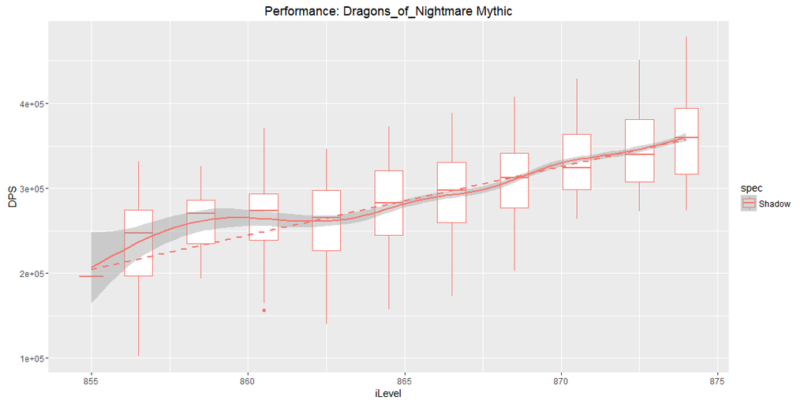

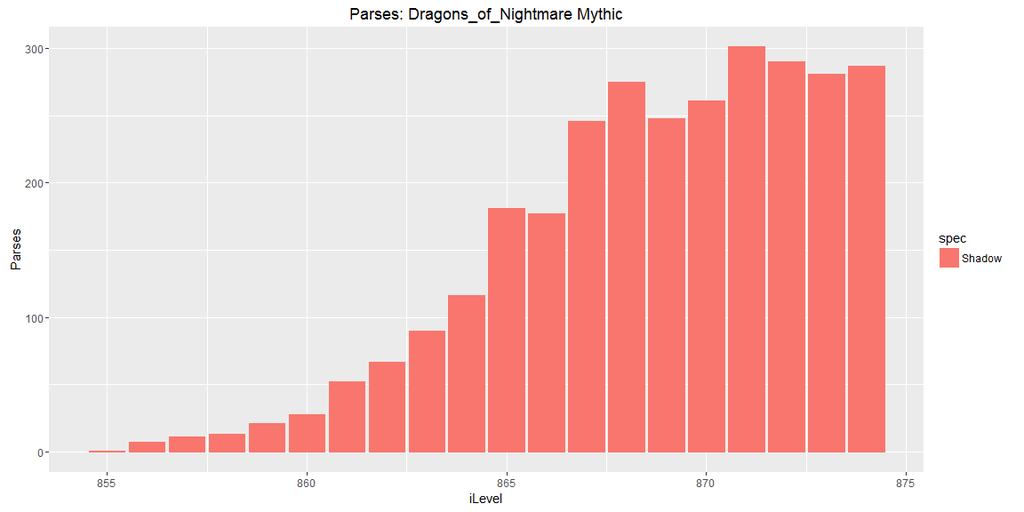

```r
plot_encounter("Dragons_of_Nightmare", "Mythic")
```